# Sesjon 12: Ikke-lineære (GLM) og hierarkiske modeller

R-workshop 2. desember, OsloMet

# Generaliserte lineære modeller (GLM)

Alle regresjoner bygger på en antakelse om at sammenhengen mellom $x$ og $y$ er lineær. Det vi si, vi antar at når $x$ øker med én enhet, er økningen i $y$ konstant på $\beta$ enheter.

Hvis dette ikke er tilfellet, må vi omkode. Om sammenhengen er ikke-lineær mellom én $x$-variabel og $y$, omkoder vi $x$. Om sammenhengen er ikke-lineær mellom y og *alle* x-variablene, omkoder vi y. Dette er tilfellet når vår avhengige variabel ikke er kontinuerlig, men kategorisk eller sensurert (den stopper på en viss verdi, for eksempel 0).

Generaliserte lineære modeller (GLM) er en familie med regresjonsmodeller laget for kategoriske og sensurerte utfall: binomisk logistisk regresjon (binær), poisson-modeller (tellinger), ordinale modeller (ordinal) og multinomisk regresjon (kategorier). I disse tilfellene gir det lite mening å snakke om en enhets økning i $y$.

For å estimere en lineær likning med slike utfall, vil statistikkprogrammet vårt gjøre flere ting:

- **omkoding av avhengig variabel** slik at den blir kontinuerlig med et teoretisk spenn mellom $-\infty$ og $\infty$.

Eksmpelvis, vil vi med en binær avhengig variabel beregne oddsen for et utfall ($\frac{ant 1}{ant 0}$) for å få en kontinuerlig variabel, for så å logtransformere denne ($log(\frac{ant 1}{ant 0})$) slik at variabelens fordeling blir “klokkeformet” (den får potensielt negative verdier).

- **trekker fra en relevant sannsynlighetsfordeling** Datagenereringsprosessen (hvordan y får verdiene sine) er antatt anderledes for slike utfall. Derfor vil statistikkprogrammet beregne sannsynligheten for utfall ved hjelp av en annen sannsynlighetsfordeling en normalfordelingen.

Eksempelvis vil binomisk logistiske regresjoner trekke fra den binomiske sannsynlighetsfordelingen.

- **maximum likelihood estimering** Dette har implikasjoner for hvordan vi estimerer modellen. Det er ikke lenger en god tilnærming å bruke minste kvadraters metode (OLS) for å estimere modellen. Derfor bruker vi maximum likelihood.

R tar hånd om både omkodingen og estimeringen for oss, men valget har implikasjoner for syntaksen vi bruker i kommunikasjonen vår med R samt for tolkningen av effektene.

## Logisitisk regresjon

### Last inn data

I dette eksmpelet jobber vi med et datasett med respondenter som enten oppgir å ha stemt på Høyre eller Fremskrittspartiet ved forrige valg. Jeg er interessert i å modellere sannsynligheten for at disse respondentene velger FrP framfor H.

Jeg begynner med å laste inn dataene og omdøper datasettet til `df`.

```r
data(kap10)
df <- kap10
```

Både binomisk logistisk regresjon og poisson-modeller kan estimeres i base-R. Vi gir beskjed om at vi ønsker å bruke ML-metode ved hjelp av funksjonen `glm()`. Forøvrig er syntaksen lik.

Derimot må vi oppgi ekstra informasjon: Hva slags sannsynlighetsfordeling skal vi trekke fra, og dermed hva slags modell skal vi bruke.

Her presiserer jeg at jeg ønsker en binomisk modell. Er du interessert i de andre typer modelller, kan du konsultere hjelpesidene med `?family()`.

```r
mod2 <- glm(FrP ~ Skepsis +
              Inntekt,
            data = df,
            family = "binomial")

summary(mod2)
```

```
##
## Call:
## glm(formula = FrP ~ Skepsis + Inntekt, family = "binomial", data = df)
##
## Deviance Residuals:
##     Min       1Q   Median       3Q      Max
## -1.5350  -0.8212  -0.5541   1.0181   2.4100
##
## Coefficients:
##             Estimate Std. Error z value Pr(>|z|)
## (Intercept) -1.92566    0.47539  -4.051 5.11e-05 ***
## Skepsis      0.42107    0.07836   5.373 7.73e-08 ***
## Inntekt     -0.21162    0.04406  -4.803 1.56e-06 ***
## ---
## Signif. codes:  0 '***' 0.001 '**' 0.01 '*' 0.05 '.' 0.1 ' ' 1
##
## (Dispersion parameter for binomial family taken to be 1)
##
##     Null deviance: 535.38  on 446  degrees of freedom
## Residual deviance: 470.96  on 444  degrees of freedom
##   (17 observations deleted due to missingness)
## AIC: 476.96
##
## Number of Fisher Scoring iterations: 4
```

Regresjonskoeffisientene er rapportert som logodds. Stigningskoeffisientent for innvandringsskepsis er, for eksempel, 0.4210722.

```r
mod2$coefficients["Skepsis"]
```

```
##   Skepsis
## 0.4210722
```

Dette sier oss ikke all verden. For å tolke svarene, bør vi derfor helt eller delvis reversere omkodingen fra GLM-modellen. Da bruker vi de samme matematiske operasjonene som da vi omkodet dataene.

#### Endringsfaktor

Vi kan finne med hvilken faktor $y$ endrer seg når $x$ øker med en enhet ved å ta eksponensen av regresjonskoeffisienen. Nå får vi relativ effekt.

```r
exp(mod2$coefficients["Skepsis"])
```

```
##  Skepsis
## 1.523594
```

```r
paste("Sannsynligheten for å stemme på FrP framfor Høyre er",
      round(exp(mod2$coefficients["Skepsis"]), 1),
      "ganger høyere for respondenter som skårer en enhet høyere på innvandringsskepsis.")
```

[output not shown]

#### Relativ effekt (i prosent)

Vi kan omkode for å få prosentvis endring. Vi trekker fra 1, og ganger opp med 100.

```r
(exp(mod2$coefficients["Skepsis"])-1)*100
```

```
##  Skepsis
## 52.35943
```

```r
paste("Sannsynligheten for å stemme på FrP framfor Høyre stiger med",
      round((exp(mod2$coefficients["Skepsis"])-1)*100),
      "% for hver enhets økning i innvandringsskepsis.")
```

[output not shown]

#### Absolutt effekt (i prosentpoent)

Vi kan reversere omkodingen totalt for å beregne endringen i sannsynligheten for å stemme på FrP. Da må vi i praksis bestemme oss for et scenario, siden alle glm-er har eksponensielle effekter (effeken av $x$ er relativ til konstantleddet). Her velger jeg å sammenlinke respondenter med 5 og 6 skårer på innvandringsskepsis.

Jeg regner ut predikert logodds…

```r
scenario1 <- sum(mod2$coefficients[1],
                   mod2$coefficients[2] * 5)

scenario2 <- sum(mod2$coefficients[1],
                   mod2$coefficients[2] * 6)
```

…deretter reverserer jeg omkodingen. Jeg kan gjøre dette for hånd, eller bruke `plogis()`-funksjonen.

```r
#ferdigfunksjon for predikert sannsynlighet
plogis(scenario1)
```

```
## [1] 0.5448044
```

```r
#for hand
exp(scenario1)/(1+exp(scenario1))
```

```
## [1] 0.5448044
```

Nå kan jeg beregne avstanden mellom disse to predikerte verdiene.

```r
abs.effekt <- plogis(scenario2) - plogis(scenario1)
abs.effekt
```

```
## [1] 0.1010285
```

```r
paste("Når skepsis øker fra 5 til 6 (og inntekt == 0), øker sannsynligheten for å stemme FrP framfor H med",
      round(plogis(scenario2) - plogis(scenario1), 2)*100,
"prosentpoeng.")
```

```
## [1] "Når skepsis øker fra 5 til 6 (og inntekt == 0), øker sannsynligheten for å stemme FrP framfor H med 10 prosentpoeng."
```

Når skepsis øker fra 5 til 6 og respondenten ikke har noen inntekt (inntekt == 0), øker sannsynligheten for å stemme FrP framfor H med 10, prosentpoeng.

### Din tur

- lag et nytt scenario hvor du lar inntekt være 10.

Her er mitt forslag.

```r
scenario3 <- sum(mod2$coefficients[1],
                   mod2$coefficients[2] * 5 ,
                   mod2$coefficients[3] * 10)

scenario4 <- sum(mod2$coefficients[1],
                   mod2$coefficients[2] * 6,
                   mod2$coefficients[3] * 10)

#Prosentvis endring når inntekt er høy
(plogis(scenario4) - plogis(scenario3))*100
```

```
## [1] 5.410262
```

## Scenarier for de viderekommende: Simulere utfallene

Fram til nå har vi antatt at feilmarginene er de samme uansett hvor i prediksjonen du er og at det beste estimatet vår er en gjennomsnittsverdi. Det er ikke alltid tilfelle; særlig når du går over til GLM-er (f.eks. logit). Da kan vi *simulere* utfall.

Jeg gjør simuleringen i `MASS`-pakken, så jeg begynner med å hente den inn fra biblioteket. Om du ikke har brukt den før, må du innstallere den først (`install.packages("MASS")`)

```r
library(MASS)
```

Pakken inneholder uheldigvis enkelte funksjoner som har samme navn som funksjoner i `dplyr`. Dette får du beskjed om når du laster pakken inn. Her er det `select()` som blir overskrevet av MASS. Om du likevel ønsker å bruke select-funksjonen fra dplyr, kan du presisere dette i koden din `dplyr::select()`.

```r
#Sjekk variablene i modellen
names(mod2$coefficients)
```

```
## [1] "(Intercept)" "Skepsis"     "Inntekt"
```

```r
#Lag scenarier: her en prekær og en ikke-prekær arbeidstaker
nyedata <- data.frame("Intercept" = 1, #Her må jeg presisere konstantleddet også
                      "Skepsis" = seq(0,10, 0.1),
                      "Inntekt" = c(5))

#Simuler
sim <-MASS::mvrnorm(
  #Antall simuleringer
  n = 10000,
  #Koeffisientene
  mu= mod2$coefficients,
  #Usikkerheten/spredningen
  Sigma= vcov(mod2)
)

#Multipliser nye koeffisienter med de hypotetiske dataene
prediksjoner <- as.matrix(nyedata) %*% t(sim)

#reverser omkodingen
prediksjoner <- plogis(prediksjoner)

#Hver linje idatasettet er nå et scenario.
dim(prediksjoner)
```

```
## [1]   101 10000
```

```r
#... og en medianverdi
median(prediksjoner[1,])
```

```
## [1] 0.04810052
```

```r
median(prediksjoner[101,])
```

```
## [1] 0.7733134
```

```r
# bruk apply() for å beregne kvantilene fra simuleringen din
kvantiler <- apply(X = prediksjoner,
                   #Margin (i == linje)
                   MARGIN = 1,
                   #Funksjonen som skal brukes på denne linjen
                   FUN = quantile,
                   #Tilleggsargument
                   na.rm = T,
                   #Enda et: 95% konfidensintervall
                   probs = c(.025,.5,.975))

#Tilt dataene slik at linje == scenario
dfp <- as.data.frame(t(kvantiler))
```

Legg de hypotetiske dataene til `dfp`.

```r
dfp <- cbind(dfp,
             nyedata)
head(dfp)
```

|  | 2.5% | 50% | 97.5% | Intercept | Skepsis | Inntekt |
| --- | --- | --- | --- | --- | --- | --- |
| 1 | 0.02179798 | 0.04810052 | 0.1024488 | 1 | 0.0 | 5 |
| 2 | 0.02307742 | 0.05006488 | 0.1052224 | 1 | 0.1 | 5 |
| 3 | 0.02434999 | 0.05211273 | 0.1080489 | 1 | 0.2 | 5 |
| 4 | 0.02571125 | 0.05422984 | 0.1106495 | 1 | 0.3 | 5 |
| 5 | 0.02717645 | 0.05639205 | 0.1132723 | 1 | 0.4 | 5 |
| 6 | 0.02873610 | 0.05868681 | 0.1161534 | 1 | 0.5 | 5 |

```r
#endre variabelnavn
names(dfp)
```

```
## [1] "2.5%"      "50%"       "97.5%"     "Intercept" "Skepsis"   "Inntekt"
```

```r
names(dfp)[2] = "Sannsynlighet for en FrP-stemme"
names(dfp)[1] = "lav"
names(dfp)[3] = "hoy"
names(dfp)[5] = "Innvandringsskepsis"
```

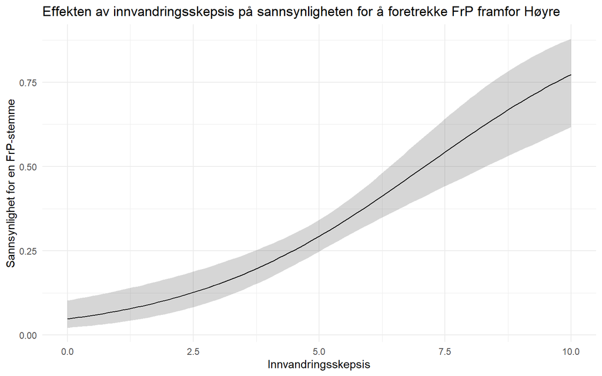

```r
library(ggplot2)

ggplot(dfp) +
  geom_line(aes(
    y = `Sannsynlighet for en FrP-stemme`,
    x = `Innvandringsskepsis`)
  ) +
  geom_ribbon(aes(ymax = hoy,
                  ymin = lav,
                  x = `Innvandringsskepsis`),
              #gjennomsiktig
              alpha = 0.2) +
  ggtitle("Effekten av innvandringsskepsis på sannsynligheten for å foretrekke FrP framfor Høyre") +
  theme_minimal()
```

# Hierarkiske modeller

Jeg begynner med å laste inn ESS data for hele Europa. Disse er naturlig hierarkiske.

```r
load("df_all.rda")
df <- df_all
```